# Causal ML: Double Selection

Simulation notebook

Michael Knaus

02/23

Goals:

- Illustrate Double Selection

# Double Selection

## Same coefficients for treatment and outcome

Consider the following DGP:

- $p=100$ covariates drawn from a multivariate normal distribution: $X \sim N(0,\Sigma)$, where $\Sigma$ is a matrix with entries $\Sigma_{kf}=0.7^{|j-k|}$
- The treatment model is $W = 1 X_1 + 0.9 X_2 + ... + 0.2 X_{9} + 0.1 X_{10} + \epsilon$, where $X_j$ is the $j$-th column of $X$ and $\epsilon \sim N(0,1)$
- The outcome model is $Y = 1 X_1 + 0.9 X_2 + ... + 0.2 X_{9} + 0.1 X_{10} + \varepsilon$, where $X_j$ is the $j$-th column of $X$ and $\varepsilon \sim N(0,4)$

This means, we are in a sparse setting where the same few variables have the same impact on treatment and outcome, but the treatment is easier to estimate (lower noise).

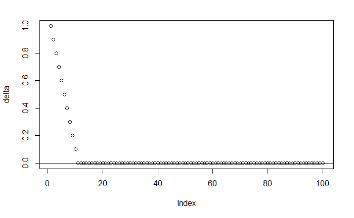

```r
library(hdm)
library(mvtnorm)
library(tidyverse)
library(estimatr)

set.seed(1234)

n = 100
p = 100

n_rep = 1000

# Define and plot parameters
theta = 1
delta = c(seq(1,0.1,-0.1),rep(0,p-10))
pi = c(seq(1,0.1,-0.1),rep(0,p-10))
cov_mat = toeplitz(0.7^(0:(p - 1)))
plot(delta)
abline(h = 0)
```

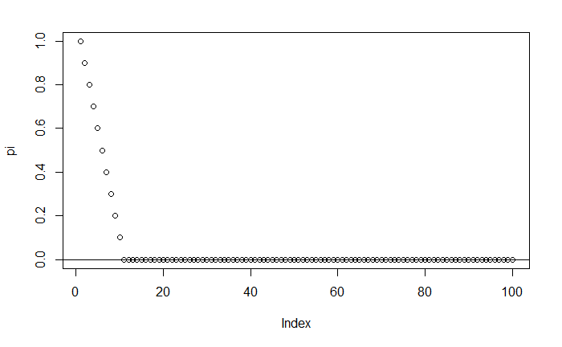

```r
plot(pi)
abline(h = 0)
```

Now, we get a first draw and check which variables are selected when running Post-Lasso on the outcome…

```r
# Generate one draw
x = rmvnorm(n = n, mean = rep(0, p), sigma = cov_mat)
w = x %*% delta + rnorm(n,0,1)
y = theta*w + x %*% pi + rnorm(n,0,4)

# Select variables in outcome regression
sel_y = rlasso(x,y)
# Which variables are selected?
which(sel_y$beta != 0)
```

```
V1 V2 V3 V4 V5 V6 V7
 1  2  3  4  5  6  7
```

and run the single-selection OLS:

```r
# Run single-selection OLS
x_sel_y = x[,sel_y$beta != 0]
summary(lm_robust(y ~ w + x_sel_y))
```

```
Call:
lm_robust(formula = y ~ w + x_sel_y)

Standard error type:  HC2

Coefficients:
            Estimate Std. Error t value  Pr(>|t|) CI Lower CI Upper DF
(Intercept)   0.3055     0.4026  0.7588 0.4499593  -0.4942    1.105 91
w             1.0987     0.3197  3.4362 0.0008908   0.4636    1.734 91
x_sel_y1      1.3978     0.6096  2.2930 0.0241541   0.1869    2.609 91
x_sel_y2      0.4160     0.8089  0.5143 0.6082751  -1.1907    2.023 91
x_sel_y3     -0.2627     0.8999 -0.2920 0.7709776  -2.0502    1.525 91
x_sel_y4      0.9067     0.6770  1.3393 0.1838142  -0.4381    2.251 91
x_sel_y5      0.6745     0.7462  0.9040 0.3683753  -0.8076    2.157 91
x_sel_y6      0.4787     0.6666  0.7182 0.4744983  -0.8454    1.803 91
x_sel_y7      1.0649     0.7102  1.4996 0.1371923  -0.3457    2.476 91

Multiple R-squared:  0.8066 ,   Adjusted R-squared:  0.7896
F-statistic: 58.53 on 8 and 91 DF,  p-value: < 2.2e-16
```

Next, let’s implement Double Selection manually by selecting also variables in the treatment regression…

```r
# Select variables in treatment regression
sel_w = rlasso(x,w)
which(sel_w$beta != 0)
```

```
V1 V2 V3 V4 V5 V6 V8
 1  2  3  4  5  6  8
```

```r
# Double selection
x_sel_union = x[,sel_y$beta != 0 | sel_w$beta != 0]
summary(lm_robust(y ~ w + x_sel_union))
```

```
Call:
lm_robust(formula = y ~ w + x_sel_union)

Standard error type:  HC2

Coefficients:
             Estimate Std. Error t value  Pr(>|t|) CI Lower CI Upper DF
(Intercept)    0.3064     0.4019  0.7622 0.4479196  -0.4921    1.105 90
w              1.2218     0.3293  3.7108 0.0003574   0.5677    1.876 90
x_sel_union1   1.3292     0.6053  2.1959 0.0306679   0.1267    2.532 90
x_sel_union2   0.3083     0.8186  0.3766 0.7073723  -1.3180    1.934 90
x_sel_union3  -0.3907     0.9037 -0.4324 0.6664811  -2.1860    1.405 90
x_sel_union4   0.7669     0.6805  1.1269 0.2627659  -0.5851    2.119 90
x_sel_union5   0.7019     0.7446  0.9427 0.3483754  -0.7773    2.181 90
x_sel_union6   0.3118     0.6926  0.4501 0.6537087  -1.0643    1.688 90
x_sel_union7   1.3222     0.7931  1.6670 0.0989880  -0.2535    2.898 90
x_sel_union8  -0.4743     0.5719 -0.8292 0.4091611  -1.6105    0.662 90

Multiple R-squared:  0.808 ,    Adjusted R-squared:  0.7888
F-statistic: 51.15 on 9 and 90 DF,  p-value: < 2.2e-16
```

This is exactly the result that the `rlassoEffect` command of the `hdm` package would provide. The only difference being that it uses slightly different robust standard errors:

```r
ds = rlassoEffect(x,y,w)
summary(ds)
```

```
[1] "Estimates and significance testing of the effect of target variables"
   Estimate. Std. Error t value Pr(>|t|)
d1    1.2218     0.3229   3.784 0.000154 ***
---
Signif. codes:  0 ‘***’ 0.001 ‘**’ 0.01 ‘*’ 0.05 ‘.’ 0.1 ‘ ’ 1
```

Lets now repeatedly draw 1000 samples and check the distribution of the resulting coefficient for single and Double Selection:

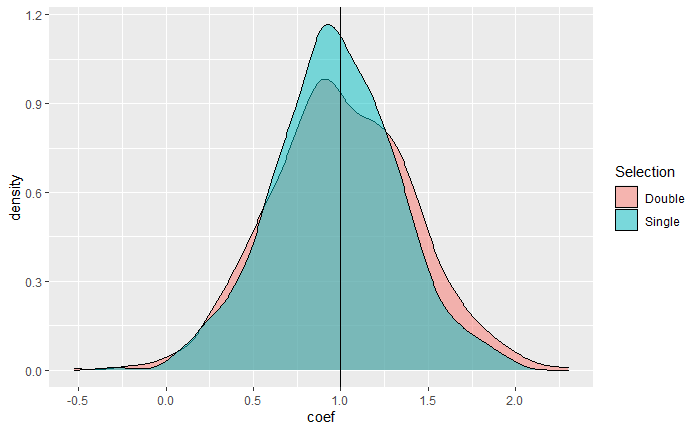

```r
results = matrix(NA,n_rep,2)
colnames(results) = c("Single","Double")

for (i in 1:n_rep) {
  x = rmvnorm(n = n, mean = rep(0, p), sigma = cov_mat)
  w = x %*% delta + rnorm(n,0,1)
  y = theta*w + x %*% pi + rnorm(n,0,4)

  sel_y = rlasso(x,y)
  x_sel_y = x[,sel_y$beta != 0]
  results[i,1] = lm(y ~ w + x_sel_y)$coefficients[2]
  results[i,2] = rlassoEffect(x,y,w)$alpha
}

as.data.frame(results) %>% pivot_longer(cols=everything(),names_to = "Selection",values_to = "coef") %>%
  ggplot(aes(x = coef, fill = Selection)) + geom_density(alpha = 0.5) + geom_vline(xintercept = theta)
```

```r
cat("Bias:\n")
```

```
Bias:
```

```r
round(colMeans(results)-theta,4)
```

```
 Single  Double
-0.0315  0.0023
```

```r
cat("\nMSE:\n")
```

```
MSE:
```

```r
round(colMeans((results-theta)^2),4)
```

```
Single Double
0.1282 0.1637
```

The single selection algorithm is a little bit biased but the variance is smaller. This is reflected in the smaller MSE $\Rightarrow$ The unbiasedness of Double Selection comes at the cost of more variance. However, given that the same variables are important in both equations, the probability to miss a variables that is very important in the treatment equation is relatively small anyways. This is going to change in the next round.

## Asymmetric coefficients for treatment and outcome

We keep everything the same but reverse the order of the non-zero coefficients in the treatment equation:

- The treatment model is $W = 0.1 X_1 + 0.2 X_2 + ... + 0.9 X_{9} + 1 X_{10} + e$, where $X_j$ is the $j$-th column of $X$ and $e \sim N(0,1)$
- The outcome model is $Y = 1 X_1 + 0.9 X_2 + ... + 0.2 X_{9} + 0.1 X_{10} + e$, where $X_j$ is the $j$-th column of $X$ and $e \sim N(0,4)$

Now missing, e.g., $X_{10}$ because of its small coefficient in $Y$ should have more severe consequences.

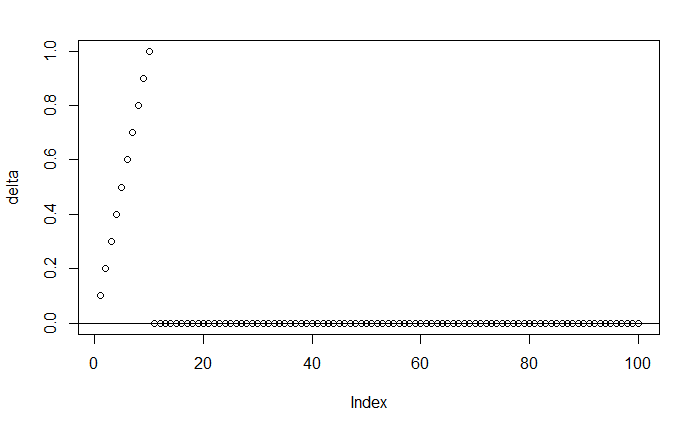

```r
# Define and plot parameters
delta = c(seq(0.1,1,0.1),rep(0,p-10))
pi = c(seq(1,0.1,-0.1),rep(0,p-10))
plot(delta)
abline(h = 0)
```

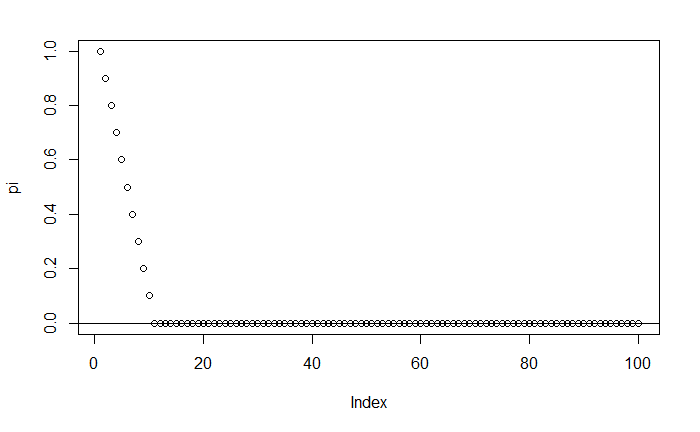

```r
plot(pi)
abline(h = 0)
```

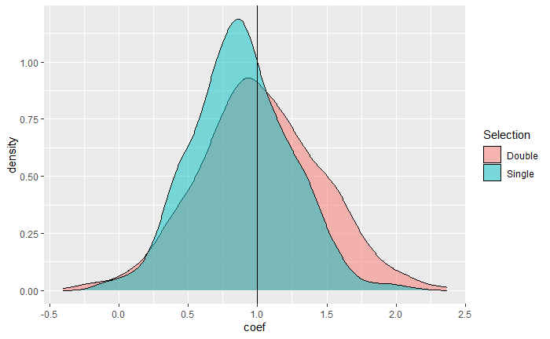

```r
results = matrix(NA,n_rep,2)
colnames(results) = c("Single","Double")

for (i in 1:n_rep) {
  x = rmvnorm(n = n, mean = rep(0, p), sigma = cov_mat)
  w = x %*% delta + rnorm(n,0,1)
  y = theta*w + x %*% pi + rnorm(n,0,4)

  sel_y = rlasso(x,y)
  x_sel_y = x[,sel_y$beta != 0]
  results[i,1] = lm(y ~ w + x_sel_y)$coefficients[2]
  results[i,2] = rlassoEffect(x,y,w)$alpha
}

as.data.frame(results) %>% pivot_longer(cols=everything(),names_to = "Selection",values_to = "coef") %>%
  ggplot(aes(x = coef, fill = Selection)) + geom_density(alpha = 0.5) + geom_vline(xintercept = theta)
```

```r
cat("Bias:\n")
```

```
Bias:
```

```r
round(colMeans(results)-theta,4)
```

```
 Single  Double
-0.1152  0.0199
```

```r
cat("\nMSE:\n")
```

```
MSE:
```

```r
round(colMeans((results-theta)^2),4)
```

```
Single Double
0.1410 0.1975
```

The bias of single selection is now more severe and visible. However, in terms of MSE it still performs better than Double Selection. Usually we are willing to accept such a loss in precision to get an unbiased estimate of the causal parameter of interest, so this is fine.

### Dense DGP

We keep the above DGP but now all variables have at least some impact $\Rightarrow$ dense setting:

- The treatment model is $W = 0.1 X_1 + 0.2 X_2 + ... + 0.9 X_{9} + 1 X_{10} + 0.1 X_{11} + ... + 0.1 X_{100} + e$, where $X_j$ is the $j$-th column of $X$ and $e \sim N(0,1)$
- The outcome model is $Y = 1 X_1 + 0.9 X_2 + ... + 0.2 X_{9} + 0.1 X_{10} + 0.1 X_{11} + ... + 0.1 X_{100} + e$, where $X_j$ is the $j$-th column of $X$ and $e \sim N(0,4)$

This is a setting where the approximate sparsity assumption is not be valid.

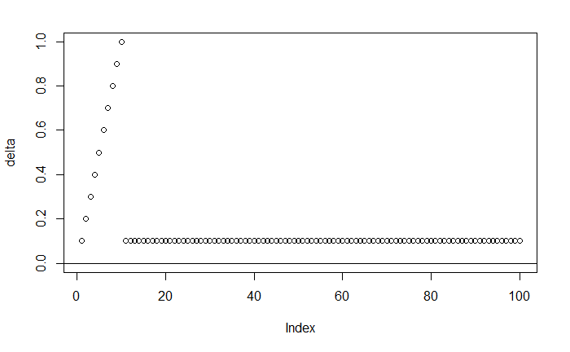

```r
# Define and plot parameters
delta = c(seq(0.1,1,0.1),rep(0.1,p-10))
pi = c(seq(1,0.1,-0.1),rep(0.1,p-10))
plot(delta, ylim = c(0, 1))
abline(h = 0)
```

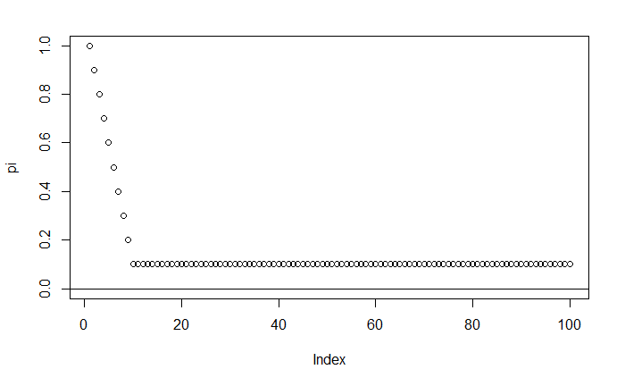

```r
plot(pi, ylim = c(0, 1))
abline(h = 0)
```

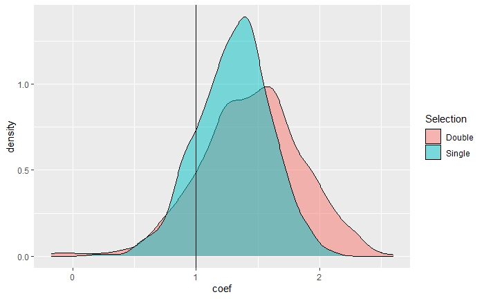

```r
results = matrix(NA,n_rep,2)
colnames(results) = c("Single","Double")

for (i in 1:n_rep) {
  x = rmvnorm(n = n, mean = rep(0, p), sigma = cov_mat)
  w = x %*% delta + rnorm(n,0,1)
  y = theta*w + x %*% pi + rnorm(n,0,4)

  sel_y = rlasso(x,y)
  x_sel_y = x[,sel_y$beta != 0]
  results[i,1] = lm(y ~ w + x_sel_y)$coefficients[2]
  results[i,2] = rlassoEffect(x,y,w)$alpha
}

as.data.frame(results) %>% pivot_longer(cols=everything(),names_to = "Selection",values_to = "coef") %>%
  ggplot(aes(x = coef, fill = Selection)) + geom_density(alpha = 0.5) + geom_vline(xintercept = theta)
```

```r
cat("Bias:\n")
```

```
Bias:
```

```r
round(colMeans(results)-theta,4)
```

```
Single Double
0.3034 0.4460
```

```r
cat("\nMSE:\n")
```

```
MSE:
```

```r
round(colMeans((results-theta)^2),4)
```

```
Single Double
0.1798 0.3685
```

Double Selection breaks down in the dense setting and becomes worse than single selection also in terms of bias.

## Take-away

- Single selection produces biased estimates even in sparse settings.
- Double Selection successfully removes omitted variable bias by variables that would be missed by single selection.
- The price to pay is a higher variance compared to the single selection estimator.
- Double Selection blows up if the world is not sparse $\Rightarrow$ we have to “bet on sparsity”, which is harder to swallow the smaller the sample size

## Suggestions to play with the toy model

Feel free to play around with the code. This is useful to sharpen and challenge your understanding of the methods. Think about the consequences of a modifications before you run it and check whether the results are in line with your expectation. Some suggestions:

- Modify DGP (correlation of covariates, coefficients, noise term, …)
- Increase the number of observations
- Implement variable selection mimicking what researchers might do (e.g. based on t-tests)